# Diccionario de términos

ixpantia

2022-07-01

## Propósito del diccionario.

El propósito de este diccionario es proveerlo con explicaciones cortas sobre los principales componentes del ixplorer. Esto le ayudará con el flujo de trabajo diario de su proyecto y a comunicar mejor con su equipo de ciencia de datos.

## ¿Qué es un proyecto?

Un proyecto es el lugar de trabajo donde se persiguen metas específicas. Dentro de un proyecto se pueden tener varios repositorios hasta la cantidad necesaria para satisfacer a la organización.

Un proyecto puede ser por ejemplo un modelo de riesgo crediticio y bajo este proyecto se puede encontrar el repositorio “analisis_exploratorio”, el repositorio “modelo” y el repositorio “paquete_r”, con lo que se mantiene el código separado de acuerdo a distintas finalidades pero todo referido a un mismo tema de proyecto.

La página del proyecto será similar a esta:

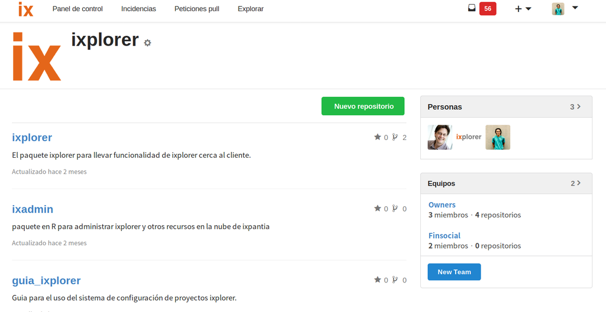

## ¿Qué es un repositorio?

Un repositorio puede ser visto como una carpeta donde se mantienen todos los archivos. Estos archivos pueden ser compartidos con otros miembros del equipo para empezar a colaborar en diferentes tiquetes que implican acciones.

[figure not shown]

Hay maneras de mantener un repositorio organizado sea que se está trabajando en un paquete o en un proyecto de RStudio con archivos R u otros.

Nuestra recomendación es:

- Tener una carpeta de datos dentro del repositorio donde se coloquen todas las fuentes de datos.
- Una carpeta de imágenes donde se incluyan las imágenes o archivos binarios.
- El .Rproject debe de ser visible
- Los scripts de R deben de estar en una carpeta y los nombres deben de ser sin espacios, puntos o combinando mayúsculas/minúsculas.

## ¿Qué es upstream?

Upstream es el nombre estándar que usamos para referirnos al repositorio “central” el cual corresponde al repositorio que contiene código limpio y funcional. Desde este repositorio central, los miembros en el equipo deberán de realizar su bifurcación para poder trabajar en sus tiquetes.

## Bifurcación

Esta es una “copia” del repositorio central. Estará bajo su nombre de usuario. Usted bifurca un repositorio cuando quiere contribuir con código al repositorio central. Al momento en que usted está listo para ofrecer sus mejoras, usted hace una solicitud de fusión. En su bifurcación (a menos de que realice una solicitud de fusión) únicamente su trabajo afectará su repositorio bifurcado, no el repositorio central. Se debe de estar atento a que todos los cambios en el repositorio central no aparecerán de manera automática en su bifurcación a menos de que siga el debido proceso con git para actualizar su repositorio.

## Tiquetes

Los tiquetes se crean para documentar acciones que necesitan ser realizadas en un repositorio. Los tiquetes pueden tener diferentes categorías:

- Pregunta: una pregunta relacionada a los temas del repositorio.
- Nuevo: una nueva característica que puede ser lograda en el código.
- Mejora: una idea u observación que puede ser realizada.
- Error: cuando algo en el código no funciona y necesita ser resuelto.
- Deseo: una característica que puede ser realizada pero no tiene prioridad.

## Hito

Una manera de organizar las prioridades de su proyecto es asignando tiquetes a cada uno de los hitos que usted define. Un ejemplo de un hito puede ser el lanzamiento de un paquete.

## Wiki

El lugar del repositorio donde se puede documentar, definir y mantener información necesaria para comunicar a su equipo para resolver dudas y mantenerse informado sobre el proyecto.

## Lanzamiento

Un lanzamientos está creado para establecer el lanzamiento de su código, lo que significa: que usted tiene una fecha límite donde el código estará listo, por lo que estará revisado, limpio y funcional.

Todo este código puede ser un paquete de R, estará etiquetado como un lanzamiento, lo que marca un punto específico en la historia del proyecto.

## COnfiguración

En este lugar se puede configurar el repositorio, las personas que tienen acceso, quiénes pueden colaborar, escribir o cambiar código. Si se desea eliminar el repositorio, cambiar derechos, este es el lugar para hacerlo.